# Project 1

### 2. Random walk on networks with fat-tailed degree distribution

```
 (a) Generate PA graph with N = 900, M = 1

Nodes     : 900
Edges     : 899
Diameter  : 16
Simulating 2000 random walk trials

 (b) Average distance and variance
```

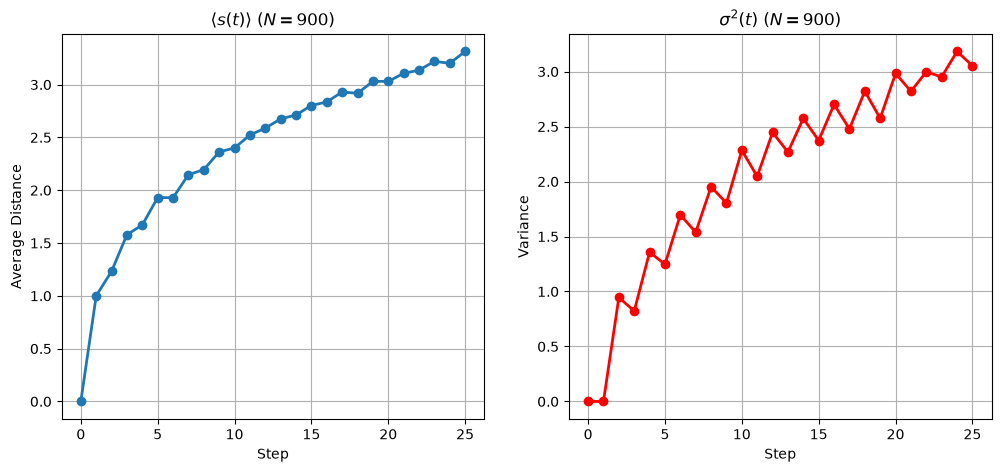

```
 (c) Degree distribution comparison
```

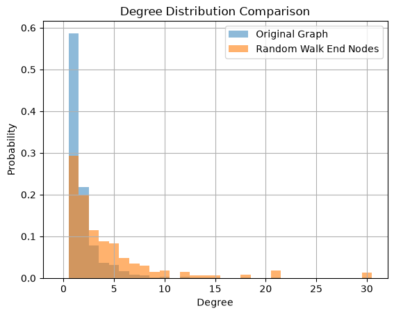

[output not shown]

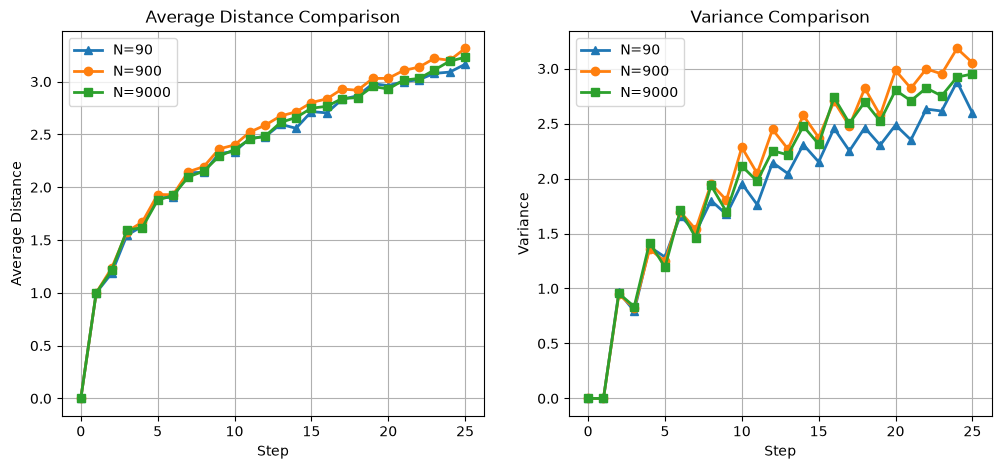

[output not shown]

```python
from project1_code import question2_2
question2_2()
```

### 3. PageRank

#### (a)

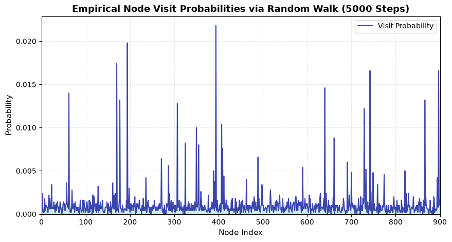

```
Node with highest in-degree: 394
Node with highest visit probability: 394
```

```python
from project1_code import question2_3a
question2_3a()
```

The plot above shows that the visit probability is proportional to the in-degree of a node (i.e., number of edges directed into a node). Over a long random walk of 5,000 steps, we observed that the node with the highest in-degree had the highest visit probability.

#### (b)

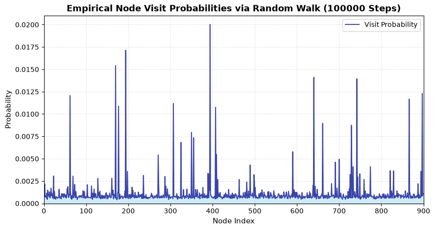

```
Node with highest in-degree: 394
Node with highest visit probability: 394
alpha=0.2, num_steps=100000
```

```python
from project1_code import question2_3b
question2_3b(alpha=0.2, num_steps=int(1e5)) # Lower alpha value
```

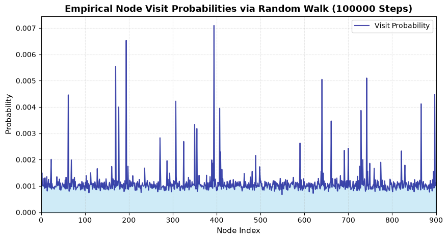

```
Node with highest in-degree: 394
Node with highest visit probability: 394
alpha=0.8, num_steps=100000
```

```python
# Higher alpha value
question2_3b(alpha=0.8, num_steps=int(1e5))
```

For PageRank with teleportation, when (i.e., the probability of teleportation) is low, the network's node degree dictates a node's visit probability, meaning the preferential hubs will have the highest visit probabilities. As shown in the first plot above, there are spikes in the probabilities around the preferential hubs.

When is high, however, the walker teleports constantly and the structure of the network is essentially ignored as the walker is teleported rather than following directed edges. The probability essentially flattens out to a uniform distribution. With 900 nodes, the uniform probability is 1/900 = 0.001, which is reflected in the higher floor centered around this value in the second graph above.

### 4. Personalized PageRank

#### (a)

```
Teleport probabilities sum: 1.0000
```

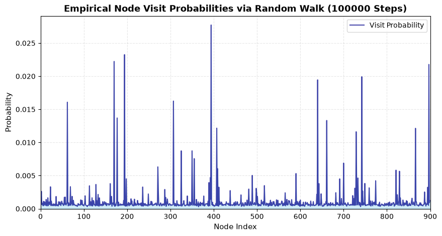

```
Node with highest in-degree: 394
Node with highest visit probability: 394
```

```python
from project1_code import question2_4a
question2_4a(alpha=0.2, num_steps=int(1e5)) # Lower alpha value
```

Because the teleportation probability =0.2 is low, the Personalized PageRank results here (with custom teleport probabilities) are similar to our 3(a) results. Since the walker doesn't teleport often, the empirical node probabilities are similar in both problems, since the walker generally follows the directed edges in the network.

#### (b)

```
Node 789 has a middle PageRank score of: 0.000272
Node 668 has a middle PageRank score of: 0.000273
The median score is: 0.000272
Median nodes: [np.int64(789), np.int64(668)]
```

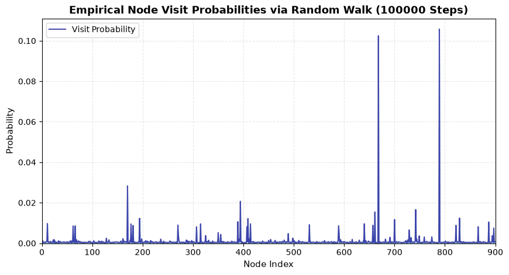

```
Node with highest in-degree: 394
Node with highest visit probability: 789
```

```python
from project1_code import question2_4b
question2_4b(alpha=0.2, num_steps=int(1e5)) # Lower alpha value
```

Because the two median nodes are the only two teleportation hubs, everytime the walker teleports, it starts at those two nodes, and the PageRank values are highest there. The empirical probabilities elsewhere are as a result of the walker moving to connected edges from those hubs.

#### (c)

The general PageRank equation

$$ \pi(i) = (1-\alpha)\sum_{j=1}^{n}\left(\frac{1}{k_{\text{out}}(j)}A_{ji}\pi(j)\right) + \frac{\alpha}{n} $$

transforms to

$$ \pi(i) = (1-\alpha)\sum_{j=1}^{n}\left(\frac{1}{k_{\text{out}}(j)}A_{ji}\pi(j)\right) + \frac{\alpha}{|T|} $$

where $T$ is a set of trusted nodes. If the node $i$ is not a trusted node, the personalized PageRank equation reduces to

$$ \pi(i) = (1-\alpha)\sum_{j=1}^{n}\left(\frac{1}{k_{\text{out}}(j)}A_{ji}\pi(j)\right) $$